# Relación entre el rendimiento en la Prueba de Transición de Matemática y factores socioeconómicos en el proceso de admisión 2022 desde una perspectiva multinivel

Geraldo Padilla, Lesa Hoffman, & Claudia Suazo

20 June, 2023

# Introducción

- El rendimiento en las pruebas de admisión es crucial para la admisión en la educación universitaria selectiva, ya que son los factores de selección que mayor ponderación suelen recibir en el puntaje compuesto que utilizan los estudiantes para postular a los programas.
- Aunque la PDT de Matemática es diseñada teniendo como referencia los Objetivos de Aprendizaje (conocimientos y habilidades) de las Bases Curriculares de Matemática de 7mo a 4to Medio, múltiples investigaciones han mostrado que la versión anterior, la PSU, tenía diferencias significativas en los niveles de rendimiento según atributos socioeconómicos de los estudiantes y/o los colegios.
- Es común encontrar en la literatura tres tipos de análisis al respecto:
  - descripción de los niveles de rendimiento en las pruebas de admisión con técnicas de investigación descriptiva (medias, medianas y proporciones por grupo),
  - comparación de los niveles de matrícula proveniente de distintos sectores socioeconómicos en el sistema de educación superior, agregando datos para cada año que son comparados en términos transversales o longitudinales,
  - ajuste de modelos de regresión lineal general (múltiple, ANOVA, o ANCOVA) o generalizados (logística binaria o multinomial, Poisson (Negative Binomial), Binomial (Beta Binomial),Tobit, Gamma, Log-Normal, cuantílica) de un nivel (**single-level**).

## Rendimiento en la PDT de Matemática y diferencias socioeconómicas entre estudiantes

## Pregunta y objetivo de investigación

De acuerdo a lo mencionado, la pregunta de interés para nuestro estudio es:

¿*Existen diferencias en el rendimiento de la PDT de Matemática entre estudiantes que puedan ser atribuidas a las características socioeconómicas indviduales y escolares que poseen*?

Por tanto, el objetivo de esta investigación es:

*Analizar la contribución que predictores socieconómicos individuales y escolares tienen sobre el rendimiento en la PDT de Matemática del año 2022 desde una perspectiva multinivel*.

# Metodología

## Diseño

Este es un estudio cuantitativo de diseño transversal, centrado en los resultados de la PDT de Matemática del año 2022. Además del análisis bivariante de los puntajes promedio en esta prueba según variables socioeconómicas individuales y escolares, se estimó un modelo de regresión lineal multinivel para analizar el efecto que variables socioeconómicas tuvieron sobre los distintos niveles de rendimiento.

## Datos

Los datos corresponden al proceso de admisión del año 2022, los cuales fueron solicitados al DEMRE a través de su [portal de bases de datos](https://demre.cl/portales/portal-bases-datos). Cabe destacar que a diferencia de procesos anteriores, el DEMRE ahora facilita un único repositorio con la información de las distintas etapas del proceso.

## Muestra

Originalmente existen 281.457 registros en la base de datos del proceso de admisión 2022 provista por el DEMRE. Según el objetivo de investigación y el análisis propuesto, dos fitros fueron aplicados:

1. El estudiante debe contar con datos válidos en todo el set de variables de análisis.
2. El colegio en el cual estudió el postulante debe contar con al menos 10 registros.

El primer filtro se aplica de cualquier modo a la muestra, ya que el modelo utiliza `eliminación por lista` (listwise deletion) para estimar los parámetros. Además, ambos filtros ayudan en la construcción de las variables de nivel 2 para los predictores de nivel 1.

La muestra final estuvo constituida por 147.562 postulantes. Sin embargo, para probar la capacidad predictiva del modelo, se utilizó validación cruzada (James et al. 2013), específicamente un conjunto de validación que representa la mitad de la muestra (seleccionada aleatoriamente según colegio [RBD]). En el primer conjunto de datos se estiman los diferentes modelos de interés hasta obtener la versión final, luego, en el conjunto de validación, se ajusta el mismo modelo y se comparan los estadísticos de ajuste.

En particular, el conjunto de entrenamiento estuvo constituido por 72.968 postulantes pertenencientes a 1405 colegios. El conjunto de validación estuvo constituido por 74.594 casos distribuidos en 1405 colegios.

## Variables

De la base de datos original, se utilizaron:

- RBD
- Sexo del estudiante
- Nivel educativo de la madre
- Nivel educativo del padre
- Tipo de escuela, Humanista o Técnico
- Sector de la escuela, Público, Particular Subvencionado o Particular pagado
- Puntaje Ranking
- Puntaje PDT Matemática

Estas variables fueron manipuladas para identificar valores perdidos, recategorizar valores, y formar un nuevo conjunto de datos. Además, se utilizaron datos del [Portal de Datos Abiertos](https://datosabiertos.mineduc.cl/) del Ministerio de Educación para fortalecer la contextualización de la experiencia educativa de los estudiantes.

Particularmente, se incluyeron las siguientes variables sobre los establecimientos educacionales:

- Territorio, Urbano o Rural
- Situación de Convenio SEP (Subvención Escolar Preferencial), Si o No
- Cobro por matrícula o mensualidad, Si o No
- Situación de Programa PACE, Si o No

Cabe destacar que esta información corresponde a los consolidados 2021 o 2022 según disponibilidad.

## Procedimiento

En primer lugar, se realizaron análisis descriptivos y correlacionales entre los predictores de interés y el rendimiento en la PDT de Matemática.

Luego, se estimaron varios modelos de regresión. El primero fue un modelo vacío (**empty model**) de dos niveles (varianza residual a nivel 1 y varianza del intercepto aleatorio a nivel 2) con la variable dependiente para estimar el Indice de Correlación Intraclase (ICC) que justifica la utilización de un modelo multinivel. Luego, se estimaron otros modelos nulos para cada predictor de nivel, los cuales ayudan a determinar si es que estas variables tienen varianza significativa a nivel 2, lo cual justificaría la creación de nuevas variables para identificar adecuadamente los efectos de cada predictor en su respectivo nivel. Cada uno de estos modelos nulos fue comparado con su versión simplificada mediante Test de Verosimilitud (Likelihood Ratio Test, o LRT) para decidir si efectos aleatorios eran necesarios.

Para los predictores de nivel 1 que mostraron varianza aleatoria significativa a nivel 2 se crearon nuevos predictores que representaran esta información. Respecto a la parametrización escogida, los modelos fueron estimados con *predictores centrados en un estadístico* a nivel 1 (en la media del grupo) y en una *constante* a nivel 2. Esto provoca que los efectos de nivel 1 se interpreten como diferencias entre estudiantes al interior de un mismo colegio (**within-effect**) y que los efectos de nivel 2 estén representando las diferencias entre colegios (**between-effect**). Sin embargo, para este artículo son de interés los **efectos contextuales** a nivel 2. Estos efectos son el resultado del efecto a nivel 2 menos el efecto a nivel 1 del predictor, los cuales se interpretan como la *contribución adicional que tiene el contexto (media del grupo) sobre el valor individual en la estimación del resultado condicional, controlando por los valores individuales dentro del grupo*. Los efectos contextuales se calcularon mediante combinaciones lineales.

Luego de ajustar los primeros modelos multinivel con los respectivos efectos a nivel 1 y nivel 2 de los predictores individuales, se agregaron los predictores a nivel 2. Estos modelos fueron estimados con Máxima Verosimilitud (direct ML) y el criterio para remover predictores de pendientes individuales fue su p-valor en el modelo, mientras que para pendientes múltiples se utilizaron Wald test multivariados (Enders 2022).

Al tener la versión final con efectos fijos, se ajustaron diversos modelos con efectos aleatorios, los cuales fueron estimados utilizando Máxima Verosimilitud Restringida (REML), ya que solo se compararon efectos aleatorios. Para el modelo final se estimaron medidas de pseudo-R^2, total R^2, pendientes pseudo-estandarizadas para los predictores con efectos aleatorios, pendientes estandarizadas para los predictores sin efectos aleatorios, y se incluyeron figuras para mejorar la representación de las estimaciones del modelo.

Por último, se estimó el modelo final con efectos fijos y aleatorios en el conjunto de datos de validación y se compararon algunos índices de ajuste entre modelos.

# Resultados

## Análisis bivariado

En términos descriptivos, se observan diferencias entre las distribuciones de los puntajes en la PDT Matemática según atributos individuales y de colegio. En la Figura 1 se puede observar una tendencia en las diferencias, donde los puntajes promedio incrementan a medida que las características socioeconómicas individuales mejoran.

La línea vertical roja representa la media de rendimiento entre los estudiantes de la muestra (505,156, sd = 109,466; según el DEMRE, los puntajes PDT se calculan con una función de densidad acumulada Normal(µ=500,σ=110)). Con este valor como referencia, se puede observar que las mujeres obtuvieron mejores puntajes promedio que los hombres. Mientras que los estudiantes de quintiles 2 a 4 alcanzaron puntajes promedio cercanos al valor muestral, entre los quintiles 1 y 5 existe una notable a favor de los últimos. En cuanto a la educación familiar, la educación del padre y la madre mostró diferencias en rendimiento a favor de estudiantes cuyo padre y/o madre alcanzó la educación superior.

Respecto a las variables de escuela, quienes asistieron a establecimientos Humanistas obtuvieron un rendimiento promedio mejor que sus pares de colegios técnicos. Los estudiantes de colegios rurales tuvieron un rendimiento promedio por debajo de la media general, al igual que los egresados de colegios con alguna forma de copago. Los estudiantes de colegios con SEP no lograron superar la media general, mientras que los egresados de colegios PACE también mostraron un rendimiento promedio por debajo de la media general. Finalmente, los estudiantes de colegios particulares privados, pese a su baja representación (11,830% de la muestra), alcanzaron la media más alta en la muestra (media = 612,985, sd = 109,018).

**Figura 1**

*Rendimiento en la PDT de Matemática según variables de caracterización*

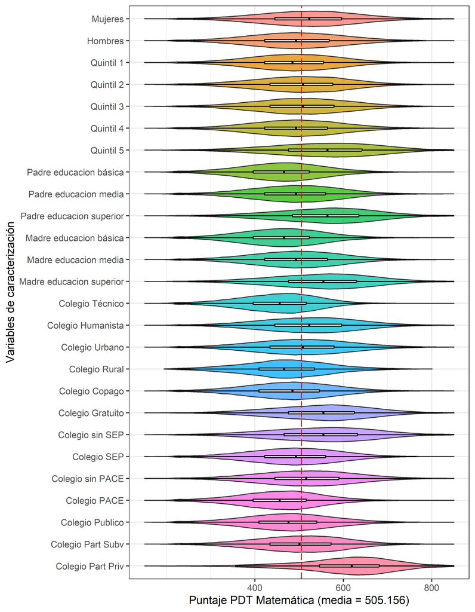

Elaboración propia con datos del proceso de admisión 2022

La Tabla 2 muestra las correlaciones entre predictores de diferentes niveles y la variable dependiente, lo cual es útil para explorar posibles inconvenientes de colinearidad en el modelo de regresión. Por ejemplo, entre la educación del padre y la madre existe una correlación estimada de 0.671. Además, se constataron altos niveles de correlación entre las variables de caracterización de la escuela, lo cual puede estar relacionado con el tipo de información que proveen.

**Tabla 2**

*Matriz de correlaciones entre las variables de interés*

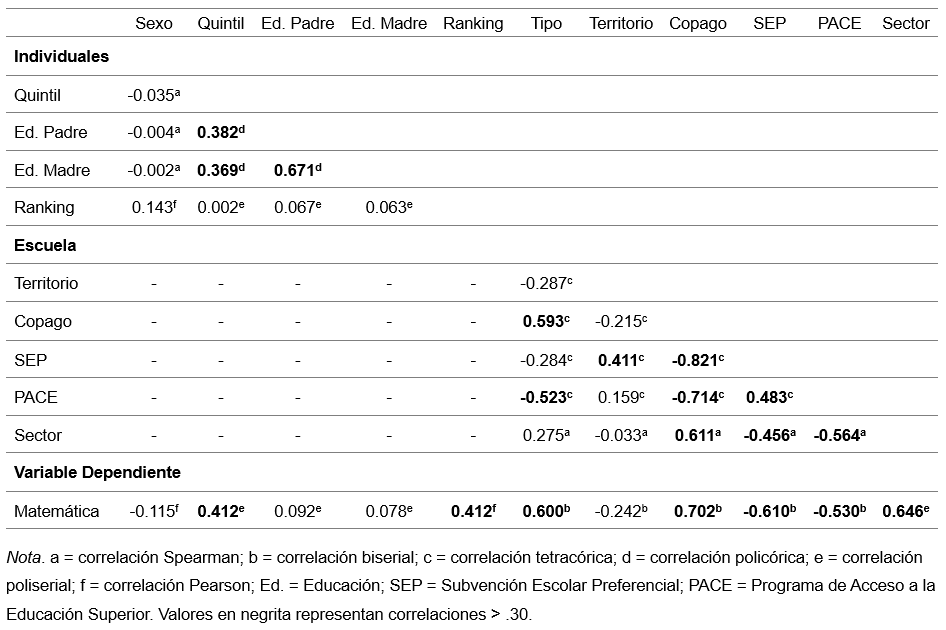

Elaboración propia con datos del proceso de admisión 2022

Una opción para reducir las dimensiones del modelo que pueden resultar redundantes es colapsar variables, aunque en este estudio no se realizó debido a la falta de una nueva variable que representara esa información. Algo que cabe destacar es que en el caso de la educación del padre y la madre se construyó la variable resumen Primera Generación, sin embargo, esta no resultó de utilidad en comparación con las variables originales.

## Análisis multinivel

A continuación se destacan los resultados más importantes de los múltiples modelos de regresión explorados.

[figure not shown]

El primer paso fue estimar un modelo multinivel vacío con la variable dependiente para calcular el ICC y establecer las fuentes de variación que cada predictor estaría tratando de reducir o explicar. La fórmula para calcular el ICC es sencilla:

```r
# Modelo vacío de un nivel
summary(lm(MATH ~ 1, data = training_data))

# Modelo vacío multinivel
Modelo_vacio_VD <- lmer(
  formula = MATH ~ 1 + (1|RBD),
  control = lmerControl(optimizer = "Nelder_Mead"),
  REML = TRUE,
  data = training_data)

# Información sobre el modelo
summary(Modelo_vacio_VD, ddf="Satterthwaite"); llikAIC(Modelo_vacio_VD, chkREML=FALSE)

# Ajuste en comparación a un modelo sin efectos aleatorios
ranova(Modelo_vacio_VD, reduce.term=TRUE) # = 0.313

# Cálculo del ICC
icc(Modelo_vacio_VD) # con función del paquete performance

icc2 <- data.frame(VarCorr(Modelo_vacio_VD),comp=c("Variance")) #Cálculo manual
round(icc2[1,4]/(sum(icc2[,4])),3) # = 0.313
```

$$\begin{align}
ICC = \frac{\tau^2_{U_0}} {\tau^2_{U_0} + \sigma^2_e}
\end{align}$$

La Tabla 3 muestra las fuentes de varianza para la variable dependiente, con un ICC = `.313`, lo cual significa que aproximadamente el 31,3% de la variabilidad de los puntajes PDT Matemática corresponden a variación entre colegios a nivel 2, o lo que es igual, que la correlación de los residuos condicionales entre estudiantes de un mismo colegio es `.313` (Hoffman 2015).

**Tabla 3**

*Partición de varianza en modelos nulos para variable dependiente y predictores de nivel 1*

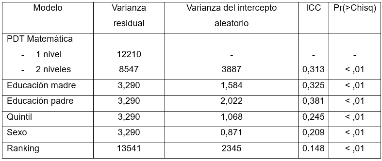

Elaboración propia con datos del proceso de admisión 2022

Como se puede observar, todos los predictores de nivel 1 tuvieron variación significativa en su intercepto aleatorio a nivel 2, por lo cual se crearon nuevas variables que representaron su contribución al modelamiento del puntaje en Matemática en distintos niveles. La varianza residual = 3,290 corresponde a la estimación de varianza a nivel 1 cuando la variable dependiente es categórica y se estima con función de enlace logit (var = `pi^2 / 3`).

El primer modelo multinivel incluyó todas las variables de interés, sin embargo, algunas pendientes no fueron significativas (como vimos en la matriz de correlaciones, la información de algunas variables fue redundante). La Tabla 4 muestra la comparación de algunas versiones estimadas. Luego de remover las variables de Convenio SEP, Copago, Territorio y Sector, se consiguió un ajuste más eficiente del modelo a los datos.

**Tabla 4**

*Índices de ajuste relativo de modelos multinivel con efectos fijos*

| Modelo | Parámetros | Predictor a remover | p-valor |
| --- | --- | --- | --- |
| Modelo completo | 30 | Convenio SEP | 0.599 |
| Modelo 2 | 29 | Copago | 0.160 |
| Modelo 3 | 28 | Territorio | 0.227 |
| Modelo 4 | 27 | Sector | 0.775 |
| Modelo 5 | 25 | - | - |

A esta nueva versión se agregaron efectos aleatorios. Tras probar distintas opciones, la solución final de predictores se detalla en la Tabla 5. Para comparar las pendientes se calcularon pendientes pseudo estandarizadas según las indicaciones de Hoffman (2015).

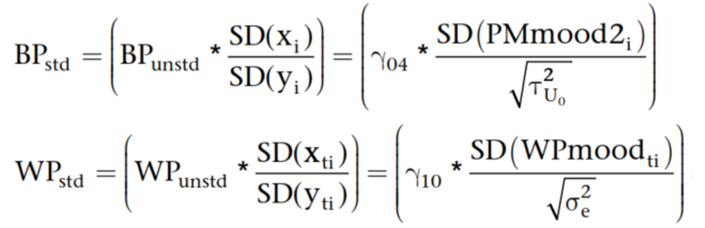

La única pendiente aleatoria que mejoró el modelo fue la de Sexo ($\tau_{U_1}^2$ = 56.73). Esto quiere decir que la diferencia estimada entre los promedios de rendimiento de hombres y mujeres de un mismo colegio no es la misma a través de la muestra. Al calcular un intervalo de confianza al 95% para este efecto aleatorio [$\gamma_{10} \pm (1,96 * \sqrt(\tau_{U_1}^2))$] podemos inferir que si bien los hombres alcanzarían un rendimiento promedio **34,049** puntos mayor que las mujeres en un mismo colegio, se espera que un 95% de la muestra tenga diferencias entre **19.286** y **48.812**.

```r
-34.049 + (1.96 * 7.532)
-34.049 - (1.96 * 7.532)
```

El modelo multinivel ha modificado la interpretación del intercepto. En un modelo regular, este sería el resultado predicho para un estudiante cuando los predictores son iguales a cero. Sin embargo, luego de añadir el segundo nivel al modelo, este valor representa la media condicional del promedio de rendimiento en la PDT Matemática de las escuelas cuando los predictores de nivel 2 son iguales a cero. En otras palabras, para un colegio hipotético con 50% de hombres, 30% de estudiantes de primer quintil y cuyos padre y madre tendrían solo educación básica, con puntaje promedio Ranking igual a 600 puntos, de tipo Técnico profesional y que no forma parte del convenio PACE. Gracias al intercepto aleatorio, podemos inferir que si bien para estos establecimientos el rendimiento estimado en la PDT Matemática es **480,554**, este rendimiento no es homogéneo en la muestra, y se espera que un 95% de la muestra tenga variaciones de rendimiento promedio entre **423.789** y **537.320**.

```r
480.554+ (1.96 * 28.962)
480.554 - (1.96 * 28.962)
```

**Tabla 5**

*Resultados modelo multinivel*

| Predictor | Coeficiente | Coeficiente estandarizado | SE | Pr(> |
| --- | --- | --- | --- | --- |
| Intercepto | 480,554 | − | 6,372 | <.01 |
| **Nivel 1** |  |  |  |  |
| Sexo (CMC) | −34,049 | −0,191 | 0,719 | <.01 |
| Quintil 2 (CMC) | −0,696 | −0,003 | 0,908 |  |
| Quintil 3 (CMC) | −3,232 | −0,013 | 1,021 | <.01 |
| Quintil 4 (CMC) | −7,152 | −0,033 | 0,911 | <.01 |
| Quintil 5 (CMC) | −7,284 | −0,029 | 1,065 | <.01 |
| Ed. Padre Media (CMC) | 6,255 | 0,036 | 0,946 | <.01 |
| Ed. Padre Superior (CMC) | 17,315 | 0,082 | 1,188 | <.01 |
| Ed. Madre Media (CMC) | 3,434 | 0,020 | 1,011 | <.01 |
| Ed. Madre Superior (CMC) | 8,204 | 0,040 | 1,224 | <.01 |
| Ranking (CMC) | 0,346 | 0,486 | 0,003 | <.01 |
| **Nivel 2** |  |  |  |  |
| Sexo (ref. 50%) | −19,991 | −0,127 | 5,106 | <.01 |
| Quintil 2 (ref. 30%) | 31,696 | 0,082 | 12,969 | <.05 |
| Quintil 3 (ref. 30%) | 14,155 | 0,025 | 15,726 | >.05 |
| Quintil 4 (ref. 30%) | −12,826 | −0,031 | 11,857 | >.05 |
| Quintil 5 (ref. 30%) | 80,626 | 0,552 | 11,102 | <.01 |
| Ed. Padre Media (ref. 30%) | 5,243 | 0,031 | 11,757 | >.05 |
| Ed. Padre Superior (ref. 30%) | 50,174 | 0,430 | 15,169 | <.01 |
| Ed. Madre Media (ref. 30%) | 35,373 | 0,201 | 12,867 | <.01 |
| Ed. Madre Superior (ref. 30%) | 74,835 | 0,425 | 16,733 | <.01 |
| Ranking (ref. 600) | 0,309 | 0,522 | 0,021 | <.01 |
| Tipo escuela (ref. Técnica) | 18,396 | 0,263 | 1,460 | <.01 |
| Escuela PACE (ref. No) | −9,935 | −0,126 | 2,565 | <.01 |

Adicionalmente, a nivel 1 podemos descatar que:

- El rendimiento estimado entre grupos socioeconómicos al interior de una misma escuela decrece a medida que aumentan los recursos económicos familiares,
- Contar con padres que hayan alcanzado la educación superior se tradujo en un incremento en los promedios de rendimiento para estudiantes de un mismo colegio,
- Los estudiantes con puntajes Ranking por encima del promedio de su colegio tendrían un mejor rendimiento en la PDT Matemática que el resto de sus compañeros/as.

A nivel 2, podemos descatar que:

- El rendimiento promedio en la PDT Matemática entre colegios disminuyó según la proporción de mujeres en el establecimiento. Por ejemplo, cada 10% de mujeres en el establecimiento se estimó una reducción en el rendimiento promedio igual a 1,9 puntos (−19,991 / 10),
- La presencia de estudiantes del mayor quintil de ingresos en lugar de estudiantes de primer quintil en el colegio se tradujo en un incremento significativo en el rendimiento predicho. Por cada 10% de estudiantes de quinto quintil, la diferencia estimada entre colegios incrementó 8 puntos (80,626 / 10),
- El nivel educacional de los padres y madres del colegio también tuvo un efecto positivo significativo sobre las diferencias en puntaje entre colegios, especialmente la educación de la madre. Por cada 10% de madres que llegaron a la educación superior, la diferencia entre colegios creció por 7,4 puntos (74,835 / 10),
- El buen rendimiento en Ranking, seguir una formación Humanista y no contar con las características que requieren de un convenio PACE también se asociaron con un incremento significativo en los niveles de rendimiento entre colegios.

Antes de finalizar, cabe destacar que el modelo analizado tuvo una capacidad explicativa del 78,4% de la varianza del intercepto aleatorio, es decir, alrededor de 3/4 del 31,3% de variación a nivel 2 que mostró el rendimiento en la PDT Matemática de los estudiantes el año 2022. Respecto a los residuos de nivel 1, el modelo fue capaz de explicar el 21,4% de la varianza residual, es decir, alrededor de 1/5 de del 68,7% de variación entre estudiantes de un mismo colegio que mostró la variable dependiente en el primer modelo vacío ajustado. En términos de resultados predichos, el modelo alcanzó un R2 cercano al 40% (0,387). Como muestra la Tabla 6, estos resultados fueron similares en el conjunto de datos de validación (el otro 50% de la muestra), lo cual robustece la precisión de los resultados del modelo analizado.

**Tabla 6**

*Índices de ajuste entre modelos según conjunto de datos**

|  | Base entrenamiento | Base validación |
| --- | --- | --- |
| **CC modelo vacío** | 0,313 | 0,281 |
| **Pseudo R2** |  |  |
| - *Intercepto aleatorio* | 0,784 | 0,787 |
| - *Varianza residual* | 0,214 | 0,203 |
| **Total R2** | 0,387 | 0,356 |

# Visualización de probabilidades

*Probabilidades estimadas según sexo y tipo de colegio*

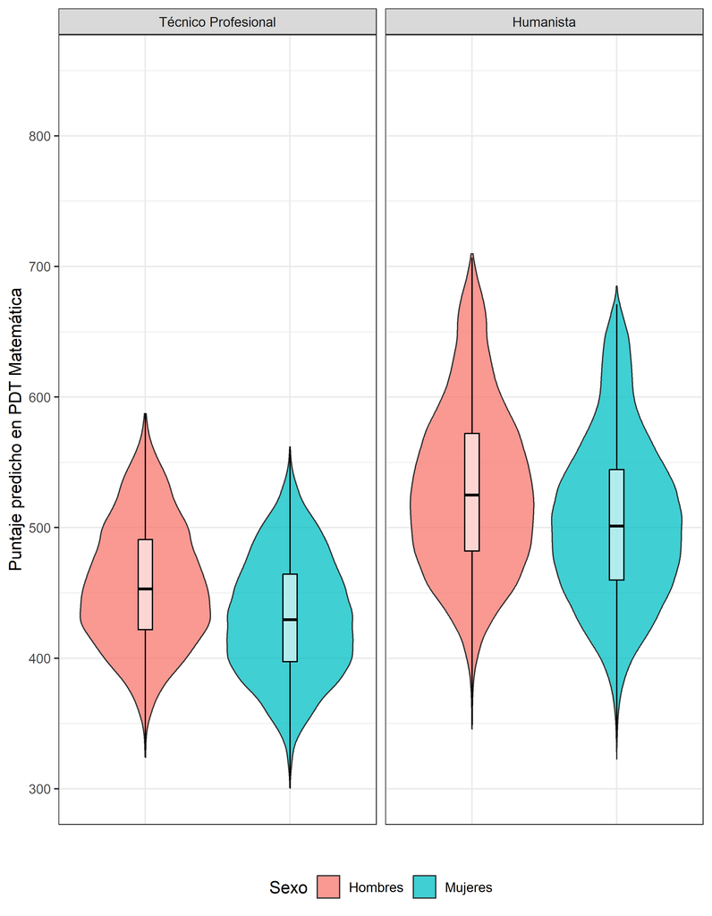

*Probabilidades estimadas según sexo y convenio PACE*

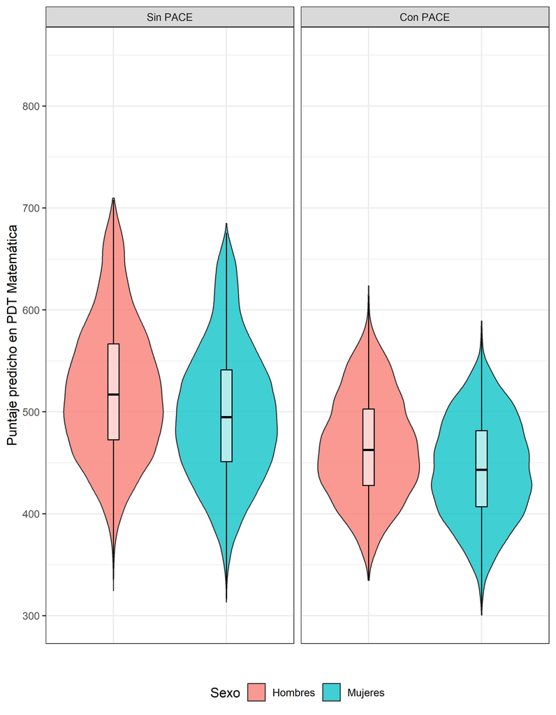

*Probabilidades estimadas según quintil de ingresos familiares percápita y tipo de colegio*

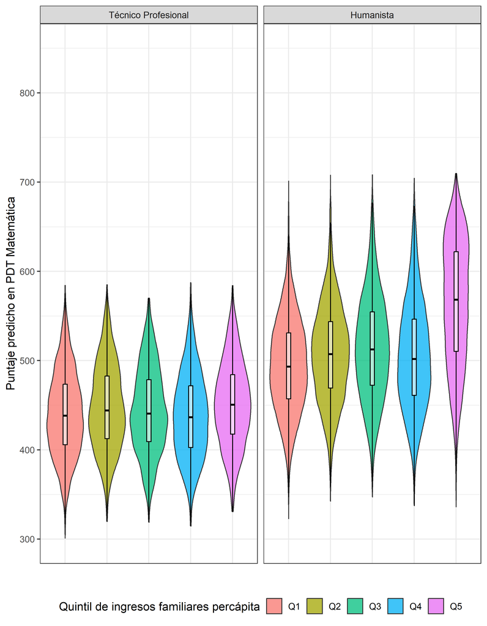

*Probabilidades estimadas según quintil de ingresos familiares percápita y convenio PACE*

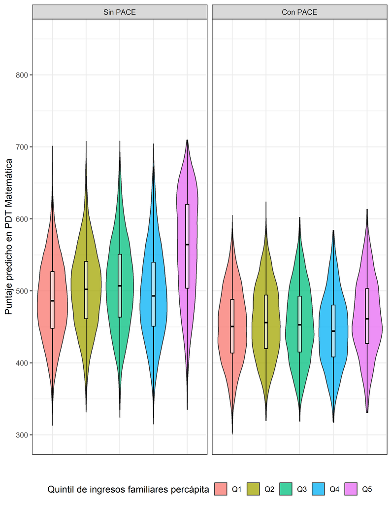

# Conclusiones (preliminares)

En relación con la pregunta de investigación sobre si existen diferencias en el rendimiento de la PDT de Matemática 2022 entre estudiantes que puedan ser atribuidas a características socioeconómicas individuales y escolares, podemos concluir que:

- Si bien a nivel individual el Ranking fue el predictor de mayor magnitud, las variables socioeconómicas mostraron una contribución significativa a la estimación del rendimiento en la PDT de Matemática entre estudiantes de un mismo colegio, especialmente el sexo y la educación del padre,
- Entre colegios, la composición de la matrícula en términos socioeconómicos mostró un efecto significativo sobre la estimación del rendimiento promedio en la PDT de Matemática. Especialmente, la proporción de estudiantes hombres, de familias clasificadas en el quintil de ingresos percápita más alto, con padre y/o madre con educación superior, y con rendimiento Ranking sobre los 600 puntos, son atributos que marcaron una diferencia favorable para los colegios.
- El modelamiento multinivel fue capaz de ajustar un modelo que alcanzó un total R2 entre 35% y 38% entre los conjuntos de datos, con efectos similares entre las pendientes, lo cual apoya la confiabilidad de sus resultados en la muestra analizada.

# Referencias

Enders, Craig K. 2022. *Applied Missing Data Analysis*. Guilford Publications.

Hoffman, Lesa. 2015. *Longitudinal Analysis: Modeling Within-Person Fluctuation and Change*. Routledge.

James, Gareth, Daniela Witten, Trevor Hastie, and Robert Tibshirani. 2013. *An Introduction to Statistical Learning*. Vol. 112. Springer.